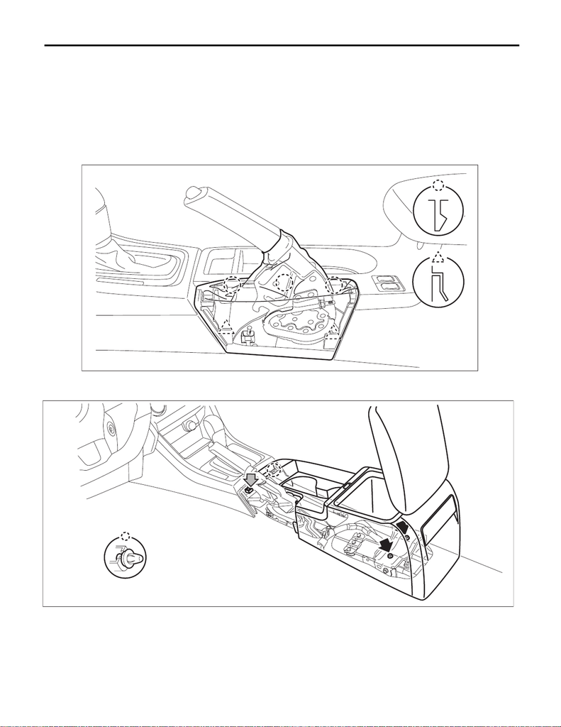

EI-67

Console Box

EXTERIOR/INTERIOR TRIM

21.Console Box

A: REMOVAL

1) Disconnect the ground cable from battery. <Ref. to NT-5, BATTERY, NOTE, Note.>

NOTE:

• For models other than STI model, disconnect the ground terminal from battery sensor.

• On CVT models, shift the select lever into “D” before disconnecting the battery ground cable.

2) Remove the console box assembly.

(1) Release the claws, and then remove the boot - hand brake.

assembly.

EI-04276

EI-04277

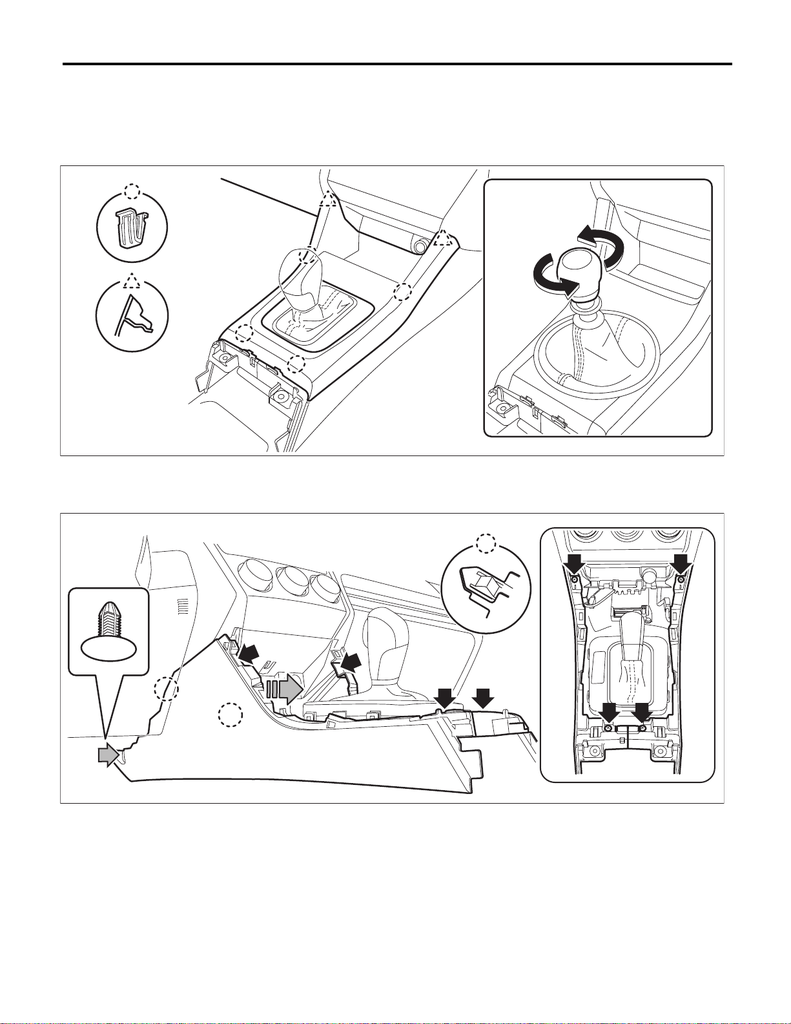

EI-68

Console Box

EXTERIOR/INTERIOR TRIM

3) Remove the cover - shift lever.

(1) Remove the shift knob. (MT model)

(2) Release the clips and claws, then pull up the cover - shift lever.

NOTE:

For vehicles with smart and STI model, disconnect harness connector.

4) Remove the left and right panel center LWR.

(1) Remove the screws and clips.

(2) Release the claws, and then pull the panel center LWR to remove.

B: INSTALLATION

1) Install the panel center LWR.

2) Install the cover - shift lever.

3) Install the console box assembly.

4) Install the boot - hand brake.

5) Connect the battery ground terminal. <Ref. to NT-5, BATTERY, NOTE, Note.>

NOTE:

For models other than STI model, connect the ground terminal to battery sensor.

EI-04260

EI-04301